# Resampling Method Notebook - Exercise solution

```r
load("GitHub/Statistical_Learning/ResamplingMethods/5.R.RData")
```

```r
names(Xy)
```

```
[1] "X1" "X2" "y"
```

1. Consider the linear regression model of y on X1 and X2. What is the standard error for beta1?

```r
m1 = lm(y~.,Xy)
```

```r
summary(m1)
```

```
Call:
lm(formula = y ~ ., data = Xy)

Residuals:
     Min       1Q   Median       3Q      Max
-1.44171 -0.25468 -0.01736  0.33081  1.45860

Coefficients:
            Estimate Std. Error t value Pr(>|t|)
(Intercept)  0.26583    0.01988  13.372  < 2e-16 ***
X1           0.14533    0.02593   5.604 2.71e-08 ***
X2           0.31337    0.02923  10.722  < 2e-16 ***
---
Signif. codes:  0 ‘***’ 0.001 ‘**’ 0.01 ‘*’ 0.05 ‘.’ 0.1 ‘ ’ 1

Residual standard error: 0.5451 on 997 degrees of freedom
Multiple R-squared:  0.1171,    Adjusted R-squared:  0.1154
F-statistic: 66.14 on 2 and 997 DF,  p-value: < 2.2e-16
```

beta1 is co-efficient fo X1. The se is 0.02593

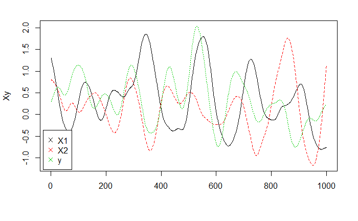

```r
matplot(Xy,type="l")
legend("bottomleft", inset=0.01, legend=c("X1","X2","y"), col=c(1:3),pch=4,
bg= ("white"), horiz=F)
```

There is very strong autocorrelation between consecutive rows of the data matrix. Roughly speaking, we have about 10-20 repeats of every data point, so the sample size is in effect much smaller than the number of rows (1000 in this case).

3. Now, use the (standard) bootstrap to estimate se . To within 10%, what do you get?

```r
alpha=function(x,y){
  cx=var(x)
  cy=var(y)
  cxy=cov(x,y)
  (cy-cxy)/(cx+cy-2*cxy)
}
alpha.fn1<-function(data, index) {
  fit1<-lm(y~., data=Xy[index,])
  coefficients(fit1)[['X1']]
}
```

```r
set.seed(1)
```

```r
boot.out=boot::boot(Xy,alpha.fn1,R=1000)
boot.out
```

[output not shown]

The standard error is 0.0287

4. Finally, use the block bootstrap to estimate se. Use blocks of 100 contiguous observations, and resample ten whole blocks with replacement then paste them together to construct each bootstrap time series. For example, one of your bootstrap resamples could be:

new.rows = c(101:200, 401:500, 101:200, 901:1000, 301:400, 1:100, 1:100, 801:900, 201:300, 701:800)

new.Xy = Xy[new.rows, ]

To within 10%, what do you get?

```r
new_index=c(1,101,201,301,401,501,601,701,801,901)
se = c()
for (i in 1:1000){
    newrows = c()
    new_start = sample(new_index,10,replace = TRUE)

    for (j in new_start){
        newrows = c(newrows,seq(j,j+99))
        }
    fit = lm(y~X1+X2, data = Xy[newrows,])

    seb1 = c(save,fit$coefficients[2])
}
sd(seb1)
```

[output not shown]